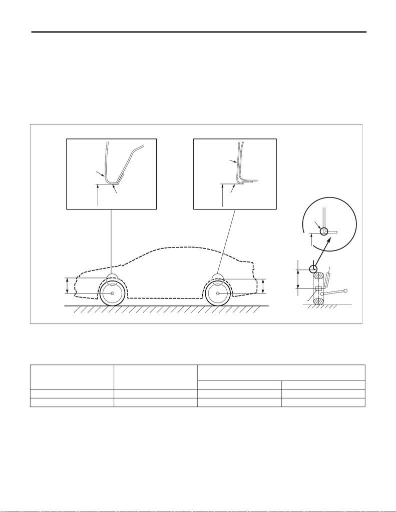

FS-11

Wheel Alignment

FRONT SUSPENSION

1. WHEEL ARCH HEIGHT

1) Park the vehicle on a level surface.

2) Empty the vehicle so that it is at “curb weight”.

NOTE:

Empty the trunk or luggage room, load the spare tire, jack and service tools, and fill up the fuel tank.

3) Set the steering wheel in a straight-ahead position, and stabilize the suspension by moving the vehicle in

a straight line for 5 m (16 ft) or more.

4) Suspend a thread from the wheel arch (point “A” in the figure below) and affix at a position directly above

the center of wheel.

5) Measure the distance between the point “A” and the center of wheel.

(1) Wheel arch height (4) Front wheel arch height (7) Point of measurement

(2) Front fender (5) Rear wheel arch height (8) End of spindle

(3) Rear quarter (6) Flange bend line

Model Tire size

Wheel arch height specification mm (in)

(Tolerance:

+12 mm

–24 mm

(

+0.47 in

–0.94 in

))

Front Rear

WRX model 235/45R17 375 (14.76) 367 (14.45)

STI model 245/40R18 370 (14.57) 362 (14.25)

FS-00655

A

A

(4)

(2)

(5)

(1)

(7)

(6)

(8)

(4)

A

(3)

(5)

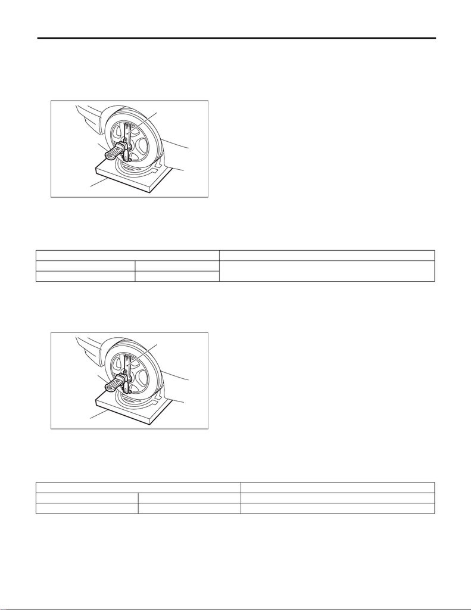

FS-12

Wheel Alignment

FRONT SUSPENSION

2. CAMBER

1) Place the front wheel on the turning radius gauge.

NOTE:

Make sure the ground contact surfaces of the front and rear wheels are at the same height.

2) Set the adapter into the center of wheel, and then set the wheel alignment gauge.

3) Measure the camber angle in accordance with the operation manual for wheel alignment gauge.

3. CASTER

1) Place the front wheel on the turning radius gauge. Make sure the ground contact surfaces of the front and

rear wheels are at the same height.

2) Set the adapter into the center of wheel, and then set the wheel alignment gauge.

3) Measure the caster angle in accordance with the operation manual for wheel alignment gauge.

(1) Alignment gauge

(2) Turning radius gauge

(3) Adapter

FS-00213

(1)

(2)

(3)

Tire size Camber (difference between RH and LH 35′ or less)

WRX model 235/45R17

–0°45′±0°30′

STI model 245/40R18

(1) Alignment gauge

(2) Turning radius gauge

(3) Adapter

FS-00213

(1)

(2)

(3)

Tire size Caster

WRX model 235/45R17 6°30′

STI model 245/40R18 6°33′

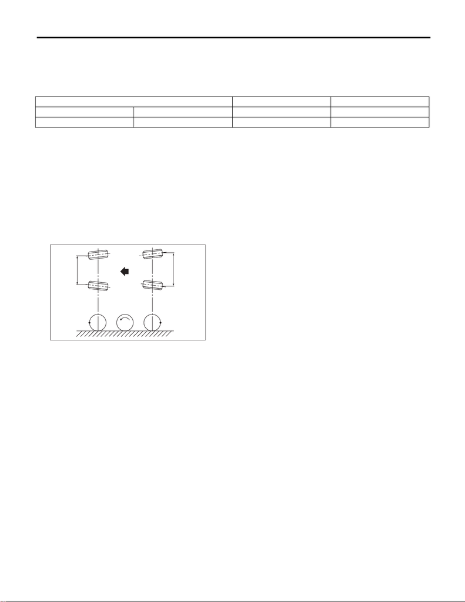

FS-13

Wheel Alignment

FRONT SUSPENSION

4. STEERING ANGLE

1) Place the vehicle on turning radius gauge.

2) While depressing the brake pedal, turn the steering wheel fully to the left and right.

3) With the steering wheel held at each fully turned position, measure both the inner and outer wheel steering

angles.

5. FRONT WHEEL TOE-IN

Toe-in: Inspection value

0

±

3 mm (0

±

0.12 in)

1) Set the toe-in gauge in the position at wheel axis center height behind the right and left front tires.

2) Place a mark at the center of both left and right tires, and measure distance “A” between the marks.

3) Move the vehicle forward to rotate the tires 180°.

NOTE:

Be sure to rotate the tires in the forward direction.

4) Measure the distance “B” between the left and right marks. Find toe-in using the following calculation:

A – B = Toe-in

6. REAR WHEEL TOE-IN

Refer to the FRONT WHEEL TOE-IN for rear toe-in inspection procedures. <Ref. to FS-13, FRONT WHEEL

TOE-IN, INSPECTION, Wheel Alignment.>

Toe-in: Inspection value

3

±

3 mm (0.12

±

0.12 in)

Tire size Inner wheel Outer wheel

WRX model 235/45R17 37.5°±1.5° 32.9°±1.5°

STI model 245/40R18 36.3°±1.5° 32.0°±1.5°

FS-00015

A

B

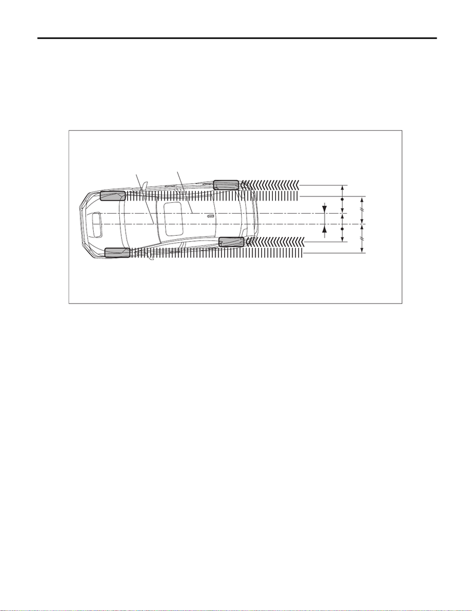

FS-14

Wheel Alignment

FRONT SUSPENSION

7. THRUST ANGLE

1) Park the vehicle on a level surface.

2) Move the vehicle 3 — 4 meters (10 — 13 feet) straight forward.

3) Draw the center of loci for both the front and rear axles.

4) Measure distance “L” between the center lines of the axle loci.

Thrust angle: Inspection value

0°

±

30

′

Less than 30

′

when “L” is 23 mm (0.9 in) or less

(a) Center line of loci (front axle) (b) Center line of loci (rear axle)

FS-00658

L

(a)

(b)

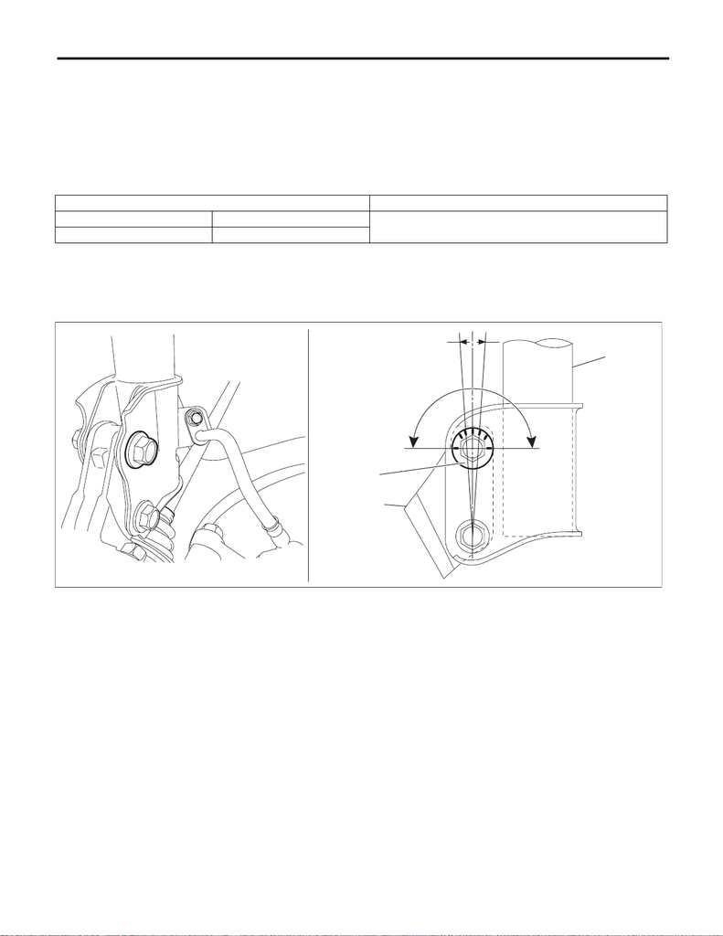

FS-15

Wheel Alignment

FRONT SUSPENSION

B: ADJUSTMENT

CAUTION:

When the wheel alignment has been adjusted, perform “VDC sensor midpoint setting mode” of the

VDC. <Ref. to VDC-16, VDC SENSOR MIDPOINT SETTING MODE, ADJUSTMENT, VDC Control Mod-

ule and Hydraulic Control Unit (VDCCM&H/U).>

1. FRONT CAMBER

1) Adjust the camber angle to the following value.

2) Loosen the two flange nuts while holding the strut bolts.

3) Turn the camber adjusting bolt so that the camber is set at specification.

NOTE:

Moving the adjusting bolt by one scale changes the camber by approximately 0°15′.

Tire size Camber (difference between RH and LH 35′ or less)

WRX model 235/45R17

–0°45′±0°30′

STI model 245/40R18

(a) Strut ASSY (d) Outer direction (g) Camber is decreased.

(b) Adjusting bolt (e) Inner direction

(c) Housing ASSY - front axle (f) Camber is increased.

FS-00513

(a)

(d)

f

(g)

(b)

(c)

(e)

( )

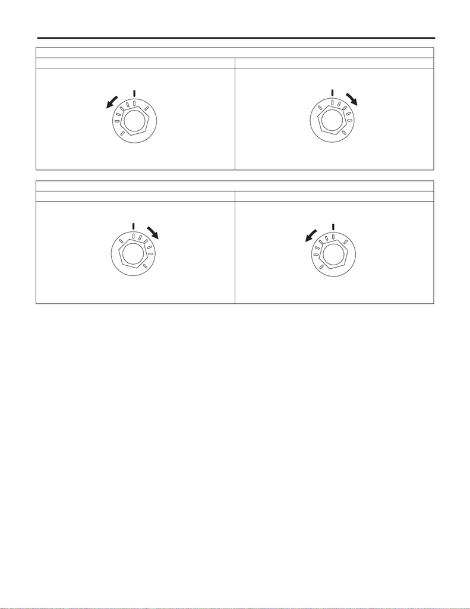

FS-16

Wheel Alignment

FRONT SUSPENSION

4) Tighten two new flange nuts.

Tightening torque:

155 N·m (15.8 kgf-m, 114.3 ft-lb)

NOTE:

While holding the adjusting bolt side, tighten the nut side.

To increase camber.

Rotate the left side counterclockwise. Rotate the right side clockwise.

To decrease camber.

Rotate the left side clockwise. Rotate the right side counterclockwise.

FS-00352 FS-00353

FS-00353 FS-00352

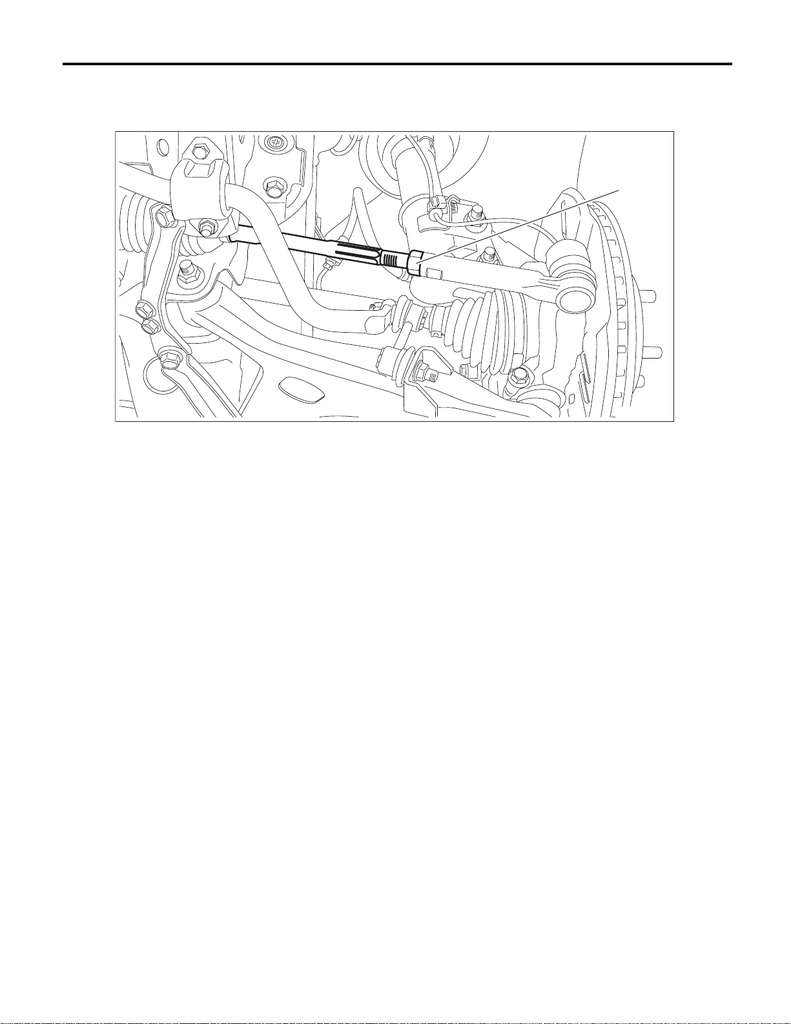

FS-17

Wheel Alignment

FRONT SUSPENSION

2. STEERING ANGLE

1) Adjust the steering angle of both inner and outer wheels.

(1) Loosen the steering tie-rod lock nut (a), and rotate the tie-rod.

(2) Turn the tie-rod to adjust the steering angle of both inner and outer wheels.

(3) Tighten the steering tie-rod lock nut (a).

Tightening torque:

85 N·m (8.7 kgf-m, 62.7 ft-lb)

NOTE:

Check and correct the tie-rod boot if twisted.

3. FRONT WHEEL TOE-IN

When adjusting the toe-in, adjust it to the following value.

Toe-in: Adjustment value

0

±

2 mm (0

±

0.08 in)

1) Check that the left and right wheel steering angles are within specification.

2) Loosen the left and right side steering tie-rod lock nuts (a).

3) Turn the left and right tie-rods by equal amounts until the toe-in is at the specification.

NOTE:

Both the left and right tie-rods are right-hand threaded. To increase toe-in, turn both tie-rods clockwise by

equal amount (viewing from the inside of vehicle).

FS-00502

(a)

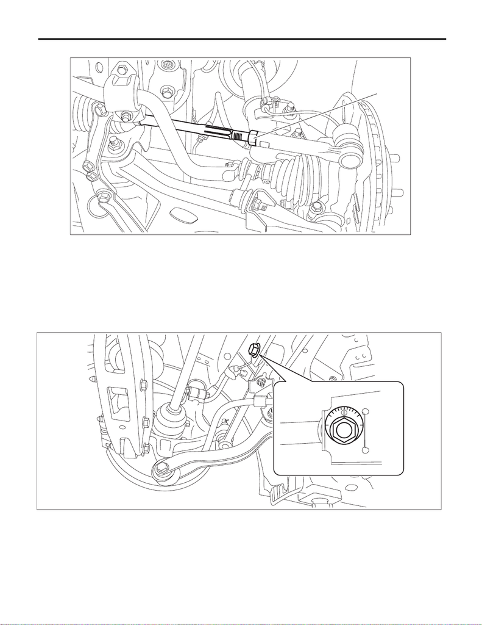

FS-18

Wheel Alignment

FRONT SUSPENSION

4) Tighten the tie-rod lock nut (a).

Tightening torque:

85 N·m (8.7 kgf-m, 62.7 ft-lb)

5) Check and correct the tie-rod boot if twisted.

4. REAR WHEEL TOE-IN

When adjusting, adjust it to the following value.

Toe-in: Adjustment value

3

±

2 mm (0.12

±

0.08 in)

1) Loosen the self-locking nut after holding the bolt head section of lateral link assembly - front.

FS-00502

(a)

RS-00536

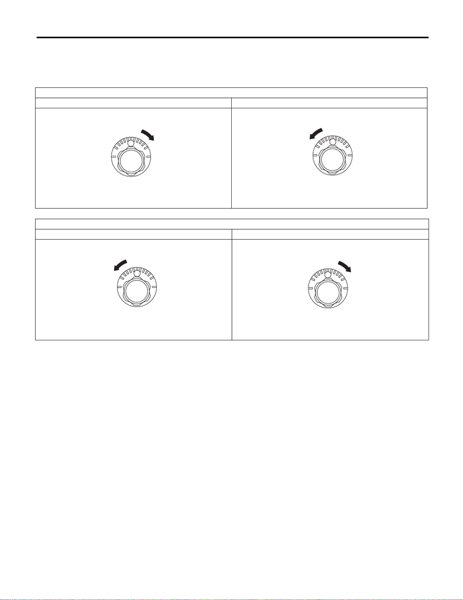

FS-19

Wheel Alignment

FRONT SUSPENSION

2) Turn the adjusting bolt until toe-in is within the specification.

NOTE:

3) Attach and tighten a new self-locking nut.

Tightening torque:

100 N·m (10.2 kgf-m, 73.8 ft-lb)

NOTE:

While holding the adjusting bolt side, tighten the nut side.

To increase toe-in.

Rotate the left side clockwise. Rotate the right side counterclockwise.

To decrease toe-in.

Rotate the left side counterclockwise. Rotate the right side clockwise.

FS-00018 FS-00019

FS-00019 FS-00018

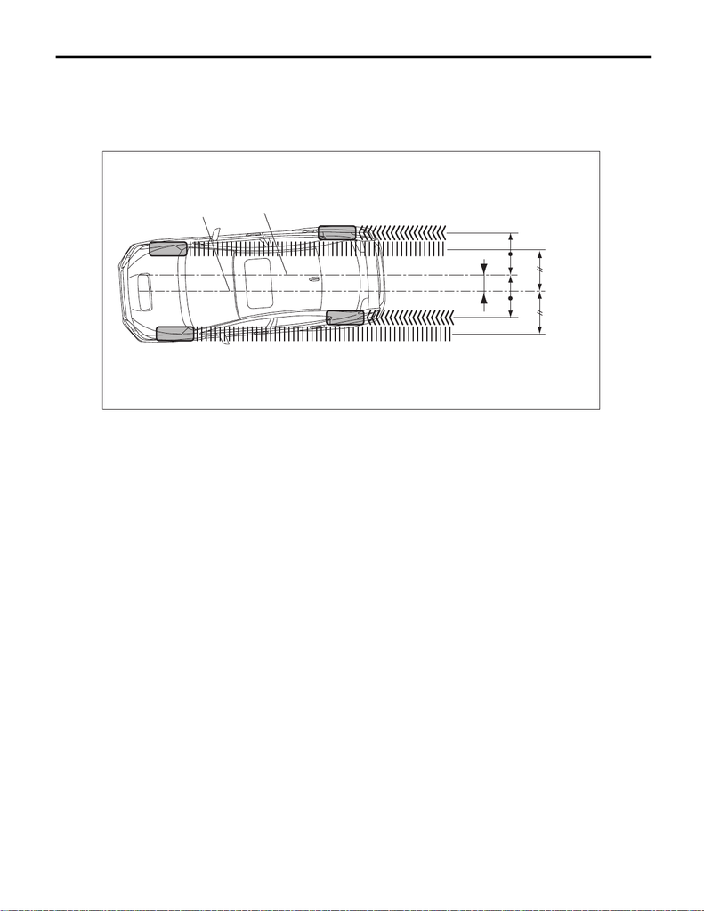

FS-20

Wheel Alignment

FRONT SUSPENSION

5. THRUST ANGLE

When adjusting, adjust it to the following value.

Thrust angle: Adjustment value

0°

±

20

′

Less than 20

′

when “L” is 15 mm (0.6 in) or less

1) Make thrust angle adjustments by turning the toe-in adjusting bolts of the rear suspension equally in the

same direction.

2) When one rear wheel is adjusted in a toe-in direction, adjust the other rear wheel equally in toe-out direc-

tion, in order to make the thrust angle adjustment.

(a) Center line of loci (front axle) (b) Center line of loci (rear axle)

FS-00658

L

(a)

(b)

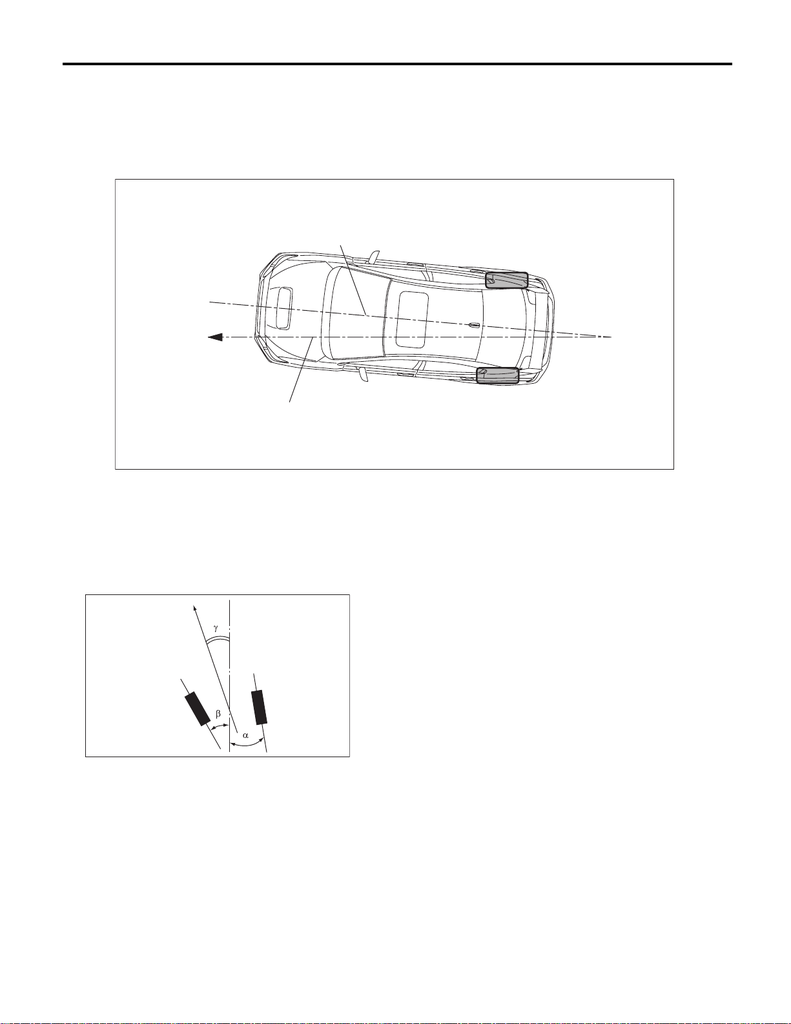

FS-21

Wheel Alignment

FRONT SUSPENSION

3) When the left and right adjusting bolts are turned by one graduation, the thrust angle will change approx. 15′.

(“L” is approx. 11 mm (0.43 in).)

NOTE:

Thrust angle is a mean value of left and right wheel toe angles in relation to the vehicle body center line.

Vehicle is driven straight in the thrust angle direction while slanting in the oblique direction depending on the

degree of the mean thrust angle.

Thrust angle:

γ

= (

α

–

β

)/2

α: Rear RH wheel toe-in angle

β: Rear LH wheel toe-in angle

(a) Thrust angle (b) Body center line

FS-00659

(a)

(b)

(1) Front

(2) Body center line

FS-00976

(1)

(2)